# Week 10. R Practice

Published

May 7, 2026

```r
library(dplyr)
library(ggplot2)
library(DescTools)
# install.packages("SuppDists")
library(SuppDists)
# install.packages("combinat")
library(combinat)
# install.packages("asht")
library(asht)
```

## Paired comparison

Suppose twins were involved in a study of cholesterol-reducing drugs. One of the twins in each pair was given drug 1 $X_i$ and the other was given drug 2 $Y_i$, where the choice was made at random.

```r
twins <- read.csv("twins.csv")
head(twins)
```

```
   X  Y
1 74 63
2 55 58
3 61 49
4 41 47
5 53 50
6 74 69
```

$D_i=Y_i-X_i$들이 서로 독립이며 중앙값 $\theta$에 대해 대칭인 분포 $F_i$를 따를 때 $H_0: \theta=0$를 검정하고자 한다.

```r
x <- twins$X; y <- twins$Y
```

### (1) Paired t-test

```r
t.test(y, x, paired=T) # t.test(y-x)
```

```
    Paired t-test

data:  y and x
t = -2.5475, df = 16, p-value = 0.02151
alternative hypothesis: true mean difference is not equal to 0
95 percent confidence interval:
 -12.178505  -1.115612
sample estimates:
mean difference
      -6.647059
```

### (2) Wilcoxon signed-rank test

```r
Ri <- rank(abs(y-x))
Vi <- sign(y-x)
T.SR <- sum(Ri[Vi>0])

Z.SR <- (T.SR-sum(Ri)/2)/sqrt(sum(Ri^2)/4)
( pnorm(abs(Z.SR), lower.tail=F)*2 )
```

```
[1] 0.02758953
```

```r
wilcox.test(y, x, paired=TRUE)$p.value # large sample test
```

```
[1] 0.02930307
```

```r
asht::wsrTest(y-x)$p.value # exact P-value
```

```
[1] 0.02563477
```

### (3) Sign test (Binomial test)

```r
n <- length(x)
SN <- sum(Vi[Vi>0])

binom.test(SN, n=n, p=0.5)$p.value # exact P-value
```

```
[1] 0.1434631
```

```r
Z.SN <- (SN-n/2)/sqrt(n/4)
( pnorm(abs(Z.SN), lower.tail=F)*2 ) # approximated P-value
```

```
[1] 0.08955507
```

Note: Sign test does not require a symmetric distribution for $D_i$.

## Randomized Complete Block Design (RCBD)

In twins example, there are 2 treatments and 17 blocks (pairs).

Extension: Matched Pairs Design $\Rightarrow$ RCBD

The data in “hay.csv” are dry matter contents (in kilograms) of hay obtained from experimental plots. The experiment was designed as a randomized complete block, and the treatments are three cutting dates (*Sept.1*, *Sept.15*, *Sept.30*).

```r
hay <- read.csv("hay.csv")
head(hay)
```

```
   kg plot   date
1 1.5    1 Sept.1
2 2.1    2 Sept.1
3 1.9    3 Sept.1
4 2.8    4 Sept.1
5 1.4    5 Sept.1
6 1.8    6 Sept.1
```

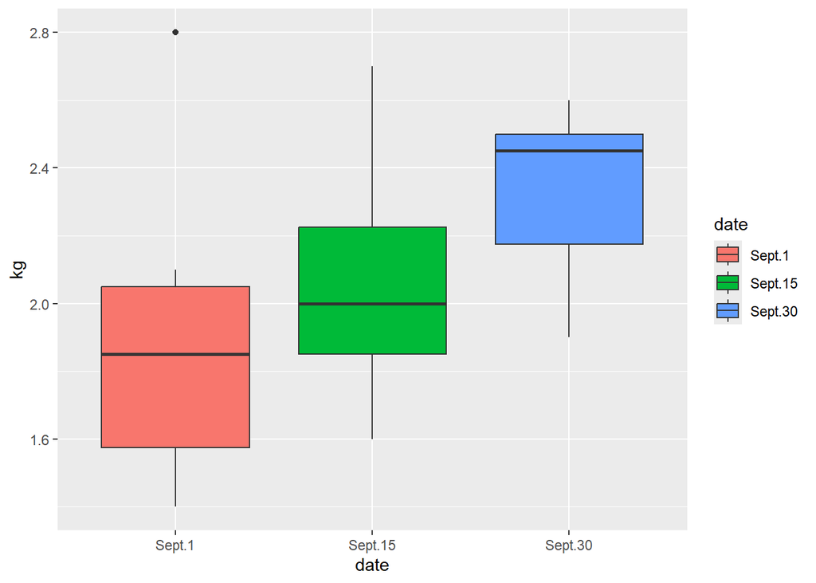

```r
hay <- hay %>% mutate(across(.cols=c(2:3), .fns=factor))

ggplot(hay, aes(x=date, y=kg, fill=date)) + geom_boxplot()
```

관측값들에 대해 다음 모형을 가정하자.

$$Y_{ij}=\mu+t_j+b_j+\epsilon_{ij}$$

- $\mu$ is an overall effect
- $t_i$’s are the treatment effects
- $b_k$’s are the block effects
- $\epsilon_{ij}$’s are i.i.d with median 0

$H_0: t_1 = \dots = t_3$를 검정하기 위해 다음의 test들을 고려할 수 있다.

### (1) F-test

```r
## Define a function to compute F-statistic
getF.CBD <- function(x, treatment, block){

  mean.trt <- tapply(x, treatment, mean)
  mean.block <- tapply(x, block, mean)
  mean.overall <- mean(x)
  k <- length(mean.trt); b <- length(mean.block)
  SSTreatment <- b*sum( (mean.trt - mean.overall)^2 )
  SSBlock = k * sum( (mean.block - mean.overall )^2 )
  SST = sum( (x - mean.overall)^2 )
  SSE = SST - SSTreatment - SSBlock
  return( (SSTreatment/(k-1)) / (SSE/((k-1)*(b-1))) )

}

# classical F-test
k <- length(unique(hay$date)); b <- length(unique(hay$plot))
F.obs <- getF.CBD(hay$kg, hay$date, hay$plot)
( p.value <-  1-pf(F.obs, k-1, (k-1)*(b-1)) )
```

```
[1] 0.01292694
```

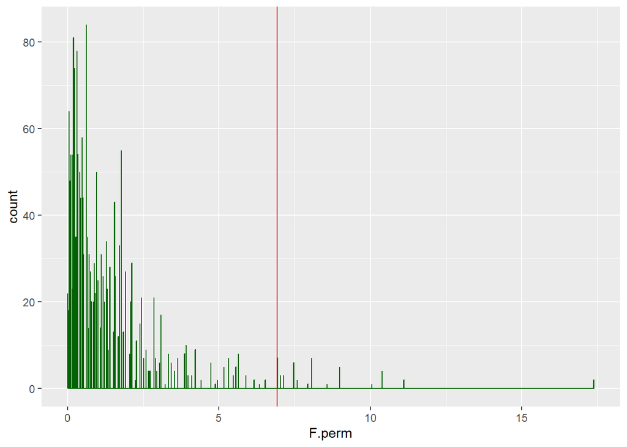

```r
# permutational F-test
Num.perm <- 1999
F.perm <- vector(length=Num.perm)
for (i in 1:Num.perm) {

  plots <- unique(hay$plot)
  date.perm <- hay$date

  # block-wise randomization
  for (j in 1:length(plots)) {
  date.perm[hay$plot == plots[j]] <- sample(hay$date[hay$plot == plots[j]], replace=FALSE)
  }

  F.perm[i] <-  getF.CBD(hay$kg, date.perm, hay$plot)
}

ggplot(data.frame(F.perm), aes(F.perm)) +
  geom_histogram(binwidth = 0.005, color="darkgreen") +
  geom_vline(xintercept=F.obs, color='red')
```

```r
( p.value <- (sum(F.perm>=F.obs)+1)/(Num.perm+1) )
```

```
[1] 0.02
```

### (2) Friedman test

```r
friedman.test(kg ~ date | plot, data=hay)
```

```
    Friedman rank sum test

data:  kg and date and plot
Friedman chi-squared = 4.3333, df = 2, p-value = 0.1146
```

```r
# friedman.test(y=hay$kg, groups=hay$date, blocks=hay$plot)
```

### (3) Aligned rank test

```r
## Define a function to compute Q-statistic
getAlignedQ.CBD <- function(x, treatment, block){

  k <- length(unique(treatment)); b <- length(unique(block))
  df <- data.frame(x=x, treatment=treatment, block=block)

  # rank blockwise-mean adjusted obs.
  df <- df %>% group_by(block) %>% mutate(x.adjusted = x-mean(x))
  df$Rij <- rank(df$x.adjusted)
  df <- df %>% group_by(treatment) %>% mutate(Ri = mean(Rij))
  df <- df %>% group_by(block) %>% mutate(Rj = mean(Rij))

  Q <- ( (k-1)/sum((df$Rij-df$Rj)^2) ) *  sum(b^2*(df$Ri-(b*k+1)/2)^2)

  return(Q)
}


( Q.obs <- getAlignedQ.CBD(hay$kg, hay$date, hay$plot) )
```

```
[1] 42.24083
```

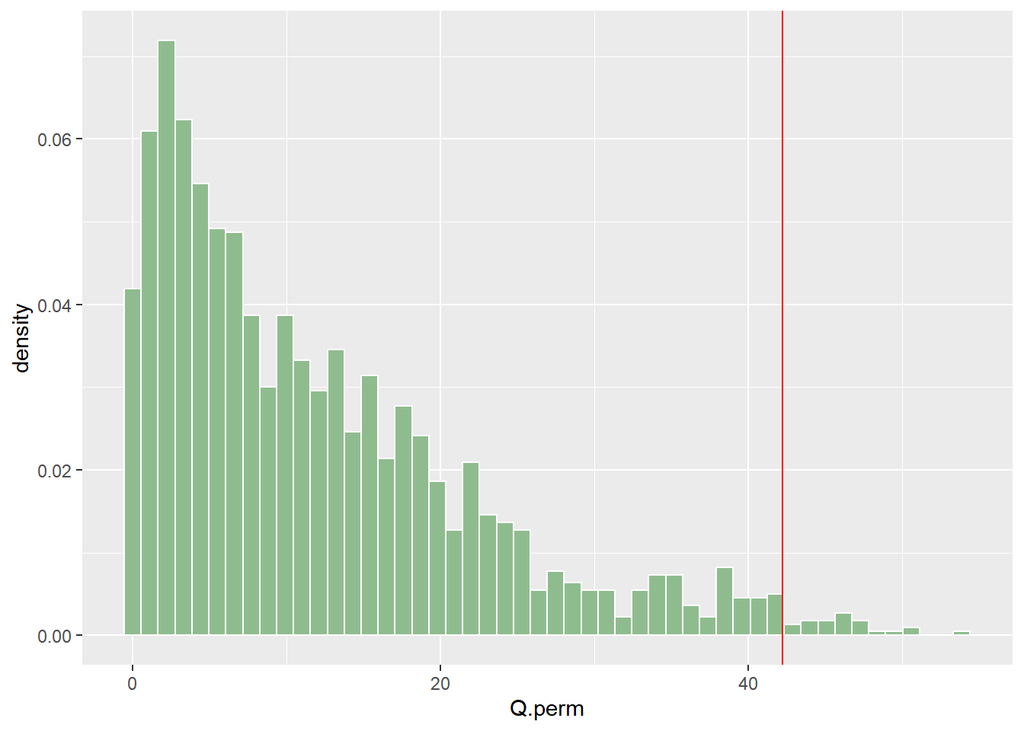

```r
Num.perm <- 1999
Q.perm <- vector(length=Num.perm)
for (r in 1:Num.perm) {

  blocks <- levels(hay$plot)
  treatment.perm <- hay$date
  # block-wise permutation
  for (j in 1:length(blocks)) {
    treatment.perm[hay$plot == blocks[j]] <-
      sample(hay$date[hay$plot == blocks[j]], replace=FALSE)
  }

  Q.perm[r] <- getAlignedQ.CBD(hay$kg, treatment.perm, hay$plot)

}

data.frame(Q.perm=Q.perm) %>% ggplot(aes(x=Q.perm)) +
  geom_histogram(aes(y=..density..), fill= "darkseagreen", color="white", bins=50) +
  geom_vline(xintercept=Q.obs, color='red')
```

```r
( p.value <- (sum(Q.perm>=Q.obs)+1)/(Num.perm+1) )
```

```
[1] 0.014
```

### (4) Page’s test for the ordered alternative: $H_a: t_1 \leq t_2 \leq t_3$

```r
DescTools::PageTest(kg ~ date | plot, data=hay) # exact test
```

```
    Page test for ordered alternatives

data:  kg and date and plot
L = 79, p-value = 0.02879
```

```r
# A normal approximation will be returned for large k & n
```

```r
# rank within a block
hay <- hay %>% group_by(plot) %>% mutate(rankinblock = rank(kg))
( ranksum <- aggregate(rankinblock ~ date, data=hay, sum) )
```

```
     date rankinblock
1  Sept.1           9
2 Sept.15          11
3 Sept.30          16
```

```r
( L.obs <- sum(c(1,2,3)*ranksum[,2]) ) # Page statistic
```

```
[1] 79
```

```r
# If the alternative hypothesis is true, we expect a large value of L.obs
```

## Measures of association

The data in “heights.csv” are the mother’s heights and daughter’s heights (in inches) of 11 mother-daughter pairs.

```r
heights <- read.csv("heights.csv")
head(heights)
```

```
  mother daughter
1     70       67
2     69       64
3     65       62
4     64       64
5     66       69
6     65       70
```

### (1) Pearson’s correlation coefficient

```r
x <- heights$mother; y <- heights$daughter
cor(x, y) # pearson
```

```
[1] 0.4569098
```

```r
cor.test(x, y)
```

```
    Pearson's product-moment correlation

data:  x and y
t = 1.541, df = 9, p-value = 0.1577
alternative hypothesis: true correlation is not equal to 0
95 percent confidence interval:
 -0.1969458  0.8294436
sample estimates:
      cor
0.4569098
```

```r
fit <- lm(y ~ x)
summary(fit)
```

```
Call:
lm(formula = y ~ x)

Residuals:
    Min      1Q  Median      3Q     Max
-5.8745 -2.3033  0.1255  1.9833  5.6485

Coefficients:
            Estimate Std. Error t value Pr(>|t|)
(Intercept)  25.0042    26.5097   0.943    0.370
x             0.6192     0.4019   1.541    0.158

Residual standard error: 3.746 on 9 degrees of freedom
Multiple R-squared:  0.2088,    Adjusted R-squared:  0.1209
F-statistic: 2.375 on 1 and 9 DF,  p-value: 0.1577
```

### (2) Spearman’s rank correlation coefficient

```r
cor(x, y, method="spearman")
```

```
[1] 0.4282821
```

```r
r <- rank(x); s <- rank(y)
( spear.r.obs <- cor(r, s) )
```

```
[1] 0.4282821
```

```r
cor.test(x, y, method="spearman") # exact test
```

```
    Spearman's rank correlation rho

data:  x and y
S = 125.78, p-value = 0.1888
alternative hypothesis: true rho is not equal to 0
sample estimates:
      rho
0.4282821
```

```r
# permutational test using spearman corr
n <- length(x)
spear.r.perm <- replicate(1999, cor(r,s[sample(1:n, n, replace=FALSE)]))
( p.value <- (sum(spear.r.perm>=spear.r.obs)+1)/2000 )*2
```

```
[1] 0.196
```

### (3) Kendall’s $\tau$

```r
tau.obs <- cor(x, y, method="kendall")
pnorm(tau.obs, sd=sqrt( (4*n+10)/(9*n*(n-1)) ), lower.tail=FALSE)*2 # large sample test
```

```
[1] 0.1829191
```

```r
( p.value <- (1-SuppDists::pKendall(tau.obs, n))*2 ) # exact test
```

```
[1] 0.1645733
```